# bak_lab4

Jakub Bąk

08 11 2020

# Zadania na czwarte laboratorium

Zadanie 1: Pobierz i wczytaj w R Studio dane załączone do tego zadania. Zawierają one informacje na temat matek i ich dzieci, u których wykryto pewną rzadko występującą wadę wrodzoną (grupa badana) lub zdrowych (grupa kontrolna).

```r
dane <- read.csv("./data/lab4-dane.csv", sep=";", header=TRUE, nrow=1768, dec = ".", na.strings = " ")
```

##Note: W pliku z zadaniem należalo dodatkowo zmienic przecinki na kropki w zmiennej MasaUr, inaczej Rstudio nie rozpoznawalo danych i traktowalo je jako character zamiast numeric, co uniemozliwialo narysowanie wykresu

Zadanie 2: Wyczyść dane (braki danych usuń przypadkami)

```r
dane <- dane[complete.cases(dane),]
```

Zadanie 3: Wyświetl podstawowe statystyki opisowe dla analizowanych zmiennych, narysuj i oceń histogramy dla zmiennych Wiek oraz MasaUr.

```r
summary(dane)
```

```
##    ď.żGrupa           MiejsceZam        Plec            MasaUr
##  Length:678         Min.   :1.00   Min.   :0.0000   Min.   :0.000
##  Class :character   1st Qu.:1.00   1st Qu.:0.0000   1st Qu.:3.250
##  Mode  :character   Median :2.00   Median :1.0000   Median :3.250
##                     Mean   :1.58   Mean   :0.5678   Mean   :3.325
##                     3rd Qu.:2.00   3rd Qu.:1.0000   3rd Qu.:3.750
##                     Max.   :2.00   Max.   :1.0000   Max.   :5.250
##      Wiek.M         KolCiazy       PoronSamo       InfOddech
##  Min.   :-1.00   Min.   :1.000   Min.   :0.000   Min.   :0.0000
##  1st Qu.:24.00   1st Qu.:1.000   1st Qu.:0.000   1st Qu.:0.0000
##  Median :28.00   Median :2.000   Median :0.000   Median :0.0000
##  Mean   :28.11   Mean   :1.882   Mean   :0.115   Mean   :0.1401
##  3rd Qu.:31.00   3rd Qu.:2.000   3rd Qu.:0.000   3rd Qu.:0.0000
##  Max.   :47.00   Max.   :9.000   Max.   :1.000   Max.   :1.0000
##     Palenie          WyksztM        Wzawodowe         Wsrednie
##  Min.   :0.0000   Min.   :1.000   Min.   :0.0000   Min.   :0.000
##  1st Qu.:0.0000   1st Qu.:2.000   1st Qu.:0.0000   1st Qu.:0.000
##  Median :0.0000   Median :3.000   Median :0.0000   Median :0.000
##  Mean   :0.0826   Mean   :2.838   Mean   :0.2286   Mean   :0.382
##  3rd Qu.:0.0000   3rd Qu.:4.000   3rd Qu.:0.0000   3rd Qu.:1.000
##  Max.   :1.0000   Max.   :4.000   Max.   :1.0000   Max.   :1.000
##     Wwyzsze
##  Min.   :0.0000
##  1st Qu.:0.0000
##  Median :0.0000
##  Mean   :0.2817
##  3rd Qu.:1.0000
##  Max.   :1.0000
```

```r
library(dplyr)
```

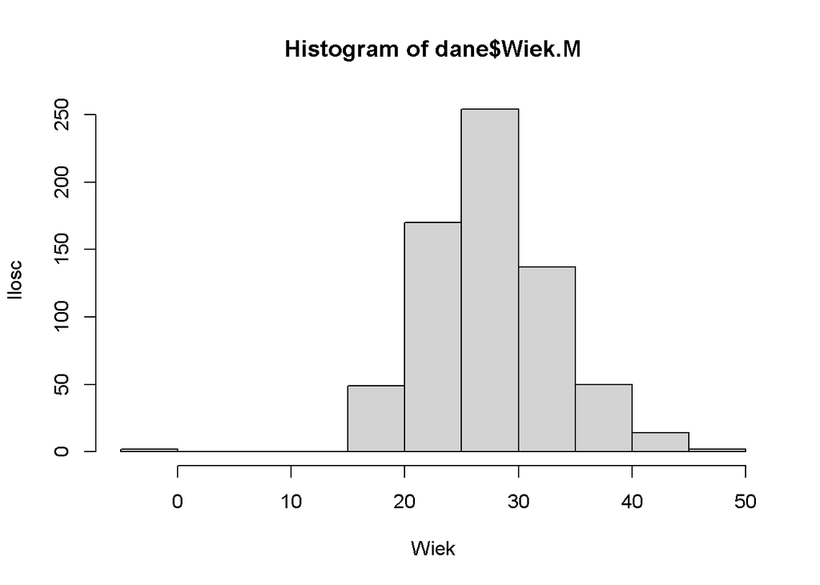

```r
hist(dane$Wiek.M, breaks=10, ylab="Ilosc", xlab="Wiek")
```

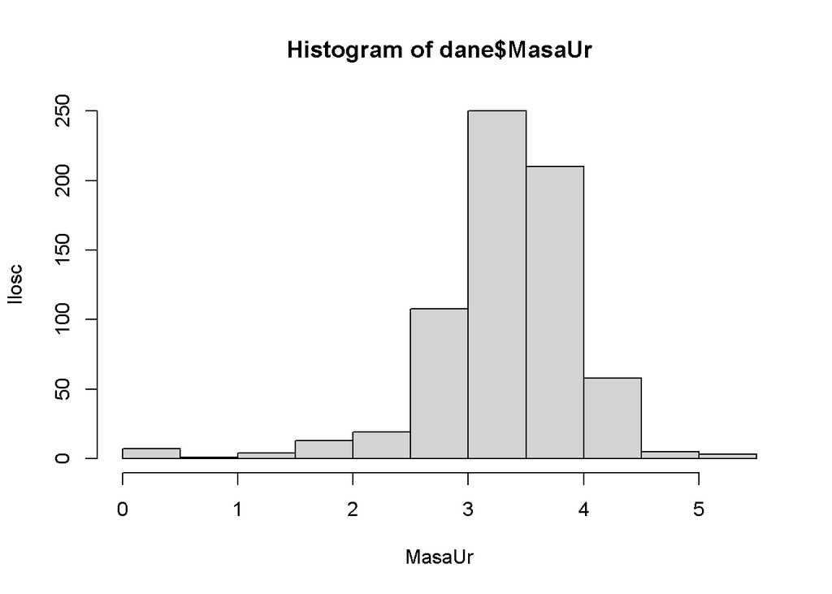

```r
dane$MasaUr <- as.numeric(dane$MasaUr)
hist(dane$MasaUr, breaks=10, ylab="Ilosc", xlab="MasaUr")
```

Ocena histogramów:

- Histogram Wiek Matki: Na wykresie możemy zobaczyc, ze wiekszosc matek podczas rodzenia byla najczesciej w wieku od 25 do 30 lat. Mozemy zobaczyc rowniez, ze w danych znajduja sie dwie wartosci -1, ktore sa najpewniej bledem w danych, w nastepnej czesci usunalem je i zastapilem srednia wartoscia
- Histogram Masa Urodzenia: Wiekszosc rodzacych sie dzieci mialo wage z przedzialu 3 do 4 kg, co jest prawidlowa waga dla dopiero co urodzonego dziecka. W tym wypadku skrajnosci z lewej strony, tzn. wagi od 0 do 2 kg wynikaja prawdopodobnie z tego, ze dzieci te byly urodzone jako wczesniaki

Zadanie 4: Utwórz model regresji logistycznej, a następnie sprawdź które zmienne mają istotny wpływ na występowanie wady u dziecka.

```r
mean_Wiek.m <- mean(dane$Wiek.M)
dane$Wiek.M[dane$Wiek.M<= 0] <- mean_Wiek.m

library(dummies)
df <- dummy.data.frame(dane, names=c("ď.żGrupa"))
df <- df[,-2]

glm.fit = glm(ď.żGrupabadana~., data = df, family = binomial)
summary(glm.fit)
```

```
##
## Call:
## glm(formula = ď.żGrupabadana ~ ., family = binomial, data = df)
##
## Deviance Residuals:
##     Min       1Q   Median       3Q      Max
## -2.2011  -0.9971  -0.7350   1.1583   1.7006
##
## Coefficients: (1 not defined because of singularities)
##             Estimate Std. Error z value Pr(>|z|)
## (Intercept)  1.82203    0.72574   2.511 0.012053 *
## MiejsceZam  -0.05589    0.17264  -0.324 0.746151
## Plec         0.43818    0.17082   2.565 0.010315 *
## MasaUr      -0.29361    0.13143  -2.234 0.025481 *
## Wiek.M      -0.02745    0.02015  -1.362 0.173058
## KolCiazy     0.28218    0.10310   2.737 0.006201 **
## PoronSamo   -0.48484    0.30679  -1.580 0.114023
## InfOddech    1.48451    0.27753   5.349 8.84e-08 ***
## Palenie      1.45259    0.41422   3.507 0.000454 ***
## WyksztM     -0.27777    0.12101  -2.295 0.021710 *
## Wzawodowe   -0.41450    0.26735  -1.550 0.121038
## Wsrednie    -0.34001    0.19574  -1.737 0.082385 .
## Wwyzsze           NA         NA      NA       NA
## ---
## Signif. codes:  0 '***' 0.001 '**' 0.01 '*' 0.05 '.' 0.1 ' ' 1
##
## (Dispersion parameter for binomial family taken to be 1)
##
##     Null deviance: 939.62  on 677  degrees of freedom
## Residual deviance: 833.60  on 666  degrees of freedom
## AIC: 857.6
##
## Number of Fisher Scoring iterations: 4
```

##Note: Zmienna grupa kontrolna nalezy zmienic za pomoca funkcji dummy w faktor, co posluzy nam potem do analizy logistycznej

Zmienne majace wplyw na wystepowanie wady u dziecka: Plec, Masa Urodzenia, Kolejna Ciaza, Przebyte infekcje oddechowe, Palenie oraz Wyksztalcenie Matki. Zmienna Wsrednie postanowilem pominac ze wzgledu na jego dosc male znaczenie.

Zadanie 5: Zbadaj współliniowość zmiennych z modelu końcowego

```r
model_koncowy <- glm(formula=ď.żGrupabadana~Plec+MasaUr+KolCiazy+InfOddech+Palenie+WyksztM, data=df, family=binomial)
summary(model_koncowy)
```

```
##
## Call:
## glm(formula = ď.żGrupabadana ~ Plec + MasaUr + KolCiazy + InfOddech +
##     Palenie + WyksztM, family = binomial, data = df)
##
## Deviance Residuals:
##     Min       1Q   Median       3Q      Max
## -2.0151  -1.0080  -0.7416   1.1608   1.6886
##
## Coefficients:
##             Estimate Std. Error z value Pr(>|z|)
## (Intercept)  0.88671    0.52091   1.702 0.088711 .
## Plec         0.47368    0.16928   2.798 0.005138 **
## MasaUr      -0.30131    0.13031  -2.312 0.020761 *
## KolCiazy     0.15016    0.07192   2.088 0.036802 *
## InfOddech    1.46971    0.27608   5.324 1.02e-07 ***
## Palenie      1.47232    0.41049   3.587 0.000335 ***
## WyksztM     -0.26434    0.09281  -2.848 0.004398 **
## ---
## Signif. codes:  0 '***' 0.001 '**' 0.01 '*' 0.05 '.' 0.1 ' ' 1
##
## (Dispersion parameter for binomial family taken to be 1)
##
##     Null deviance: 939.62  on 677  degrees of freedom
## Residual deviance: 841.18  on 671  degrees of freedom
## AIC: 855.18
##
## Number of Fisher Scoring iterations: 4
```

```r
step(model_koncowy, direction = "backward")
```

```
## Start:  AIC=855.18
## ď.żGrupabadana ~ Plec + MasaUr + KolCiazy + InfOddech + Palenie +
##     WyksztM
##
##             Df Deviance    AIC
## <none>           841.18 855.18
## - KolCiazy   1   845.68 857.68
## - MasaUr     1   846.70 858.70
## - Plec       1   849.09 861.09
## - WyksztM    1   849.39 861.39
## - Palenie    1   857.09 869.09
## - InfOddech  1   873.97 885.97
```

```
##
## Call:  glm(formula = ď.żGrupabadana ~ Plec + MasaUr + KolCiazy + InfOddech +
##     Palenie + WyksztM, family = binomial, data = df)
##
## Coefficients:
## (Intercept)         Plec       MasaUr     KolCiazy    InfOddech      Palenie
##      0.8867       0.4737      -0.3013       0.1502       1.4697       1.4723
##     WyksztM
##     -0.2643
##
## Degrees of Freedom: 677 Total (i.e. Null);  671 Residual
## Null Deviance:       939.6
## Residual Deviance: 841.2     AIC: 855.2
```

```r
library(car)
vif(model_koncowy)
```

```
##      Plec    MasaUr  KolCiazy InfOddech   Palenie   WyksztM
##  1.032225  1.038438  1.023455  1.015541  1.041446  1.085061
```

Zadanie 6: Wykonaj analizę modelu końcowego za pomocą szans.

```r
exp(coef(model_koncowy))
```

```
## (Intercept)        Plec      MasaUr    KolCiazy   InfOddech     Palenie
##   2.4271420   1.6058928   0.7398504   1.1620185   4.3479883   4.3593579
##     WyksztM
##   0.7677141
```